# High-order gene identification in spatial transcriptomics data

jinzhuang dou @ kenchen’ lab (MDACC)

March 29, 2022

This guide will demonstrate the usage of high-order gene detection in spatial transcriptomics data.

#### Stage 1: Load spatial transcriptomics data

More data information can be seen in Fig2 (https://www.nature.com/articles/s41586-021-04217-4)

```r
# Load data
library(Seurat)
obj <- readRDS(file="./../ST_tumor/data/tumor_slideSeq.RDS")
```

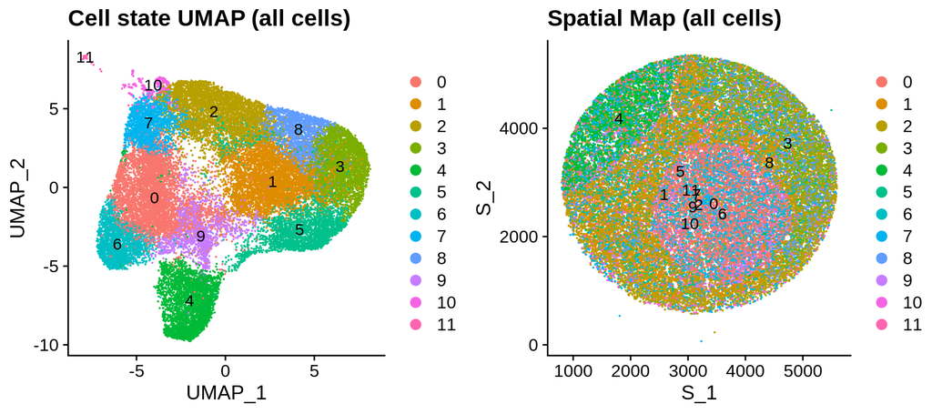

```r
library(ggpubr)
p11 <- DimPlot(obj,label=T) + ggtitle("Cell state UMAP (all cells)")
p12 <- DimPlot(obj, label=T, reduction = "spatial") + ggtitle("Spatial Map (all cells)")
p1 <- ggarrange(p11,p12,ncol=2)
p1
```

```r
tumor <- subset(obj,cells=rownames(obj@meta.data)[obj@meta.data$celltype=="tumor"])
Idents(tumor)<-tumor@meta.data$region
DEGs <- FindAllMarkers(tumor, only.pos = FALSE,logfc.threshold = 0, min.pct = 0.1)
```

Visualize the tumor cells only in cell state UMAP (left) and spatial map (right).

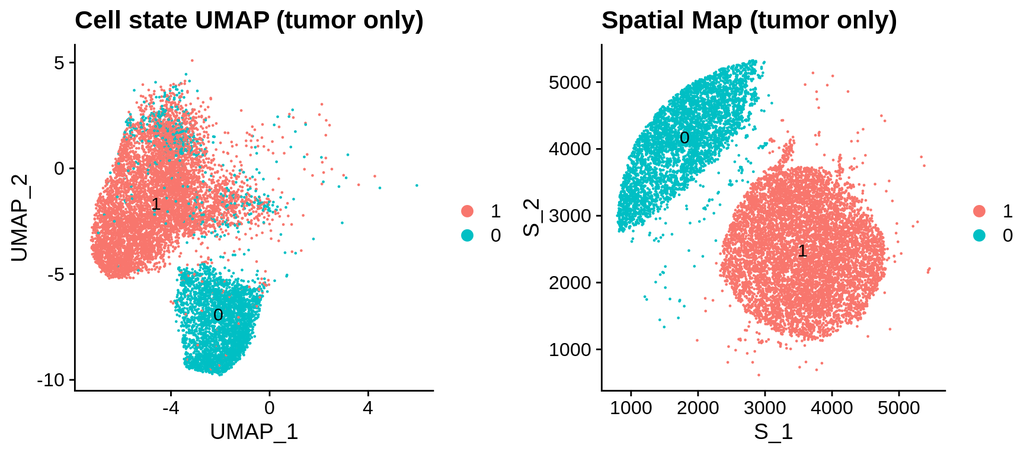

```r
library(ggpubr)
p21 <- DimPlot(tumor,label=T) + ggtitle("Cell state UMAP (tumor only)")
p22 <- DimPlot(tumor, label=T, reduction = "spatial") + ggtitle("Spatial Map (tumor only)")
p2 <- ggarrange(p21,p22,ncol=2)
p2
```

#### Stage 2: High-order DEGs detection between tumor clone 0 and 1

Make sure the `factor` and `sample` be the same in `single` mode. `obj`: Seurat object  
`factor`: Specify the phenotype column. `factor` column should be included in `obj@meta.data`  
`sample`: Specify the sample column. `reduction` column should be included in `obj@meta.data`  
`assay`: Specify the assay storing the expression level data  
`K`: Specify the dimension of CCA space for gene differential detection (default:20)  
`genelst`: Specify the variable gene list. If not specificed, the programe will determine genes with `min.frac>0.1` in at least one population.  
`mode`: Specify the running mode. If `single`, there are no replicated samples. If `multiple`, there should be at least 2 samples in eacch condition.  
`min.frac` Specfiy the gene filtering (default:0.1).

```r
source("../source/DEG.R")
out <-HighOrder_Test(obj=tumor,
                     factor="region",
                     sample="region",
                     assay="RNA",
                     K = 20,
                     genelst=NULL,
                     T_latent=10^(-5),
                     mode="single",
                     min.frac = 0.1)
```

```
## Single sample mode started!
```

```
## A total of 2080 genes are used for testing
```

```
## Perform high-order gene change detection...
```

```
## Perform permutation to generate the null model...
```

```
## 12 informative latent factors were detected
```

```
## Finished!
```

#### Stage 3: Comparison between High-order DEGs detection and traditional fold-changed based method

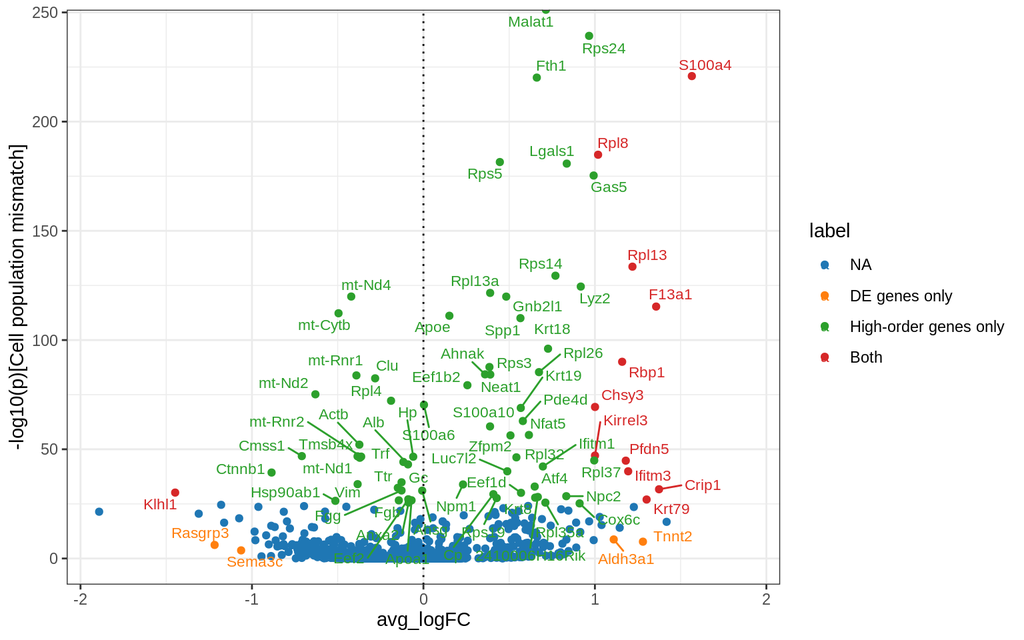

```r
overlap <- intersect(rownames(out$sum_score), DEGs$gene)
dt <- out$sum_score[overlap,]
dt$avg_logFC <- DEGs[overlap,c("avg_logFC")]
dt$p_adj<- DEGs[overlap,c("p_val_adj")]

p <-DEGs_plot(dt=dt,T1=1,T2=10,T3=25,size=3)
p
```

In above figure, x-axis shows the log_FC value and y-axis shows the p value of population-level mismatch score. There are genes showing high population-level mismatch score but low log_FC value. Two typical examples are Clu and Apoe, which are key inhibitors of tumor cell proliferation. In clone 1, Clu gene is highly expressed in the tumor clone boundary, indicating immune-tumor interaction events happening.

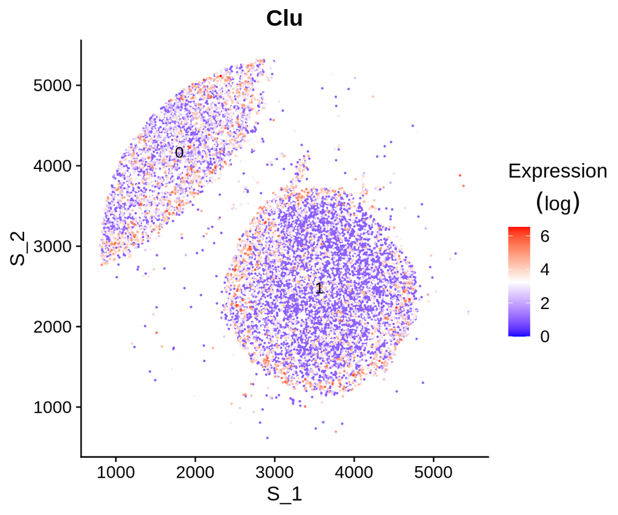

```r
p3 <- FeaturePlot(tumor,features=c("Clu"),reduction = "spatial",min.cutoff = 1, label=T)
p3<-customize_Seurat_FeaturePlot(p3, expression.threshold = 0,gradient.use = c( "blue", "white", "red"))
p3
```

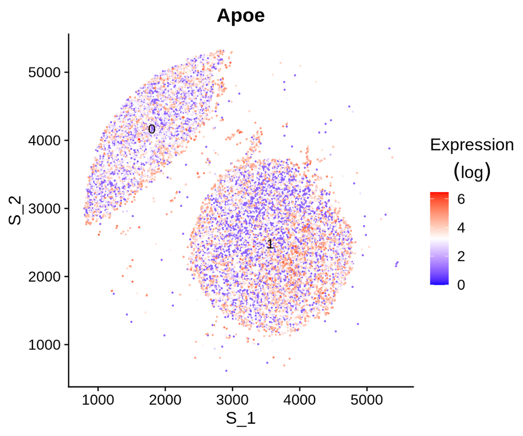

```r
p4 <- FeaturePlot(tumor,features=c("Apoe"),reduction = "spatial",min.cutoff = 1, label=T)
p4<-customize_Seurat_FeaturePlot(p4, expression.threshold = 0,gradient.use = c( "blue", "white", "red"))
p4
```